# Text Prediction App

popotam  
2014-12-14

### The App

I have created a ShinyApp.io text prediction widget  
that can be used to predict the best next word for a given phrase.

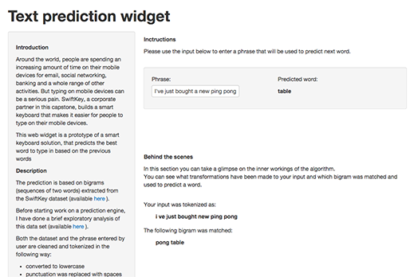

The app is available at: https://popotam.shinyapps.io/prediction_app/

### Instruction

The app is very easy to operate.

Just enter any phrase into the phrase input box  
and after some delay a predicted word will appear to the right.

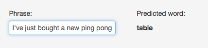

If you are interested in what's going on behind the scenes,  
there is more output data below the prediction box.

Also, on the left pane there is an explanation of the algorithm.

### The Algorithm

Word prediction is based completelly on matching words present in input phrase with bigrams extracted from the dataset.

The dataset is cleaned by converting the text to lowercase, replacing all punctuation with spaces and then removing all non-whitespace and non-ascii letter characters. Then text is split into words (ommiting the stopwords) and the most frequent bigram for each starting word is saved as a prediction material.

The input phrase is cleaned and tokenized in the same way as the dataset.

Then the last word from the phrase is matched with bigrams to produce a prediction. If word is not matched, the second last word is tried, etc.

### Thank you!

## See the app, already…

### https://popotam.shinyapps.io/prediction_app/

You will be able to enter any phrase and see what comes next.